# 5_visual_key

UNK Bio

2025-08-31

```r
library(tidyverse)
library(moments)
```

## Homework: Visualizing data

**Directions:**

Please complete all computer portions in an `rmarkdown` document knitted as an html. Upload any “by hand” calculations as images in the HTML or separately on *Canvas*.

### Helpful hint

**HINT**: For 3.5, consider just making a vector of the values of interest for a histogram.

For example, see the following. For reference:

- `c` means “concatenate”, or place things together in an object.

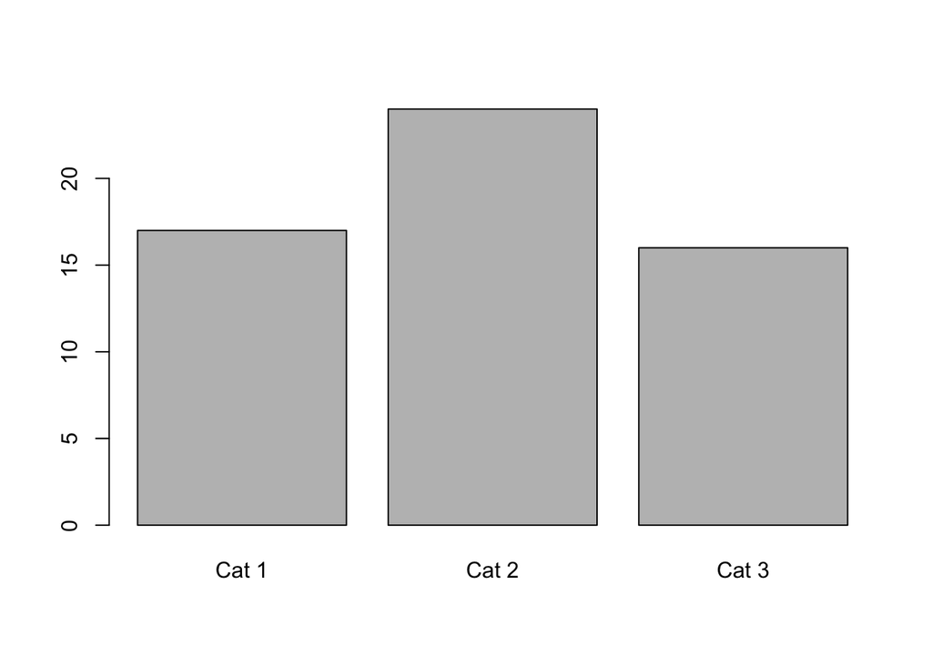

```r
# numeric vector data for counts
y <- c(17,24,16)

# manually create a histogram using barplot
barplot(y,
        # axis names must be true
        axisnames = T,
        # input names here
        # each category as a separate quoted character string
        names.arg = c("Cat 1", "Cat 2", "Cat 3"))
```

### Problem 1

The Research Institute Nature and Forest in Brussels, Belgium, conducted a survey of fish from the southern North Sea to help with the identification of fish from seabird diets [@verstraete_photos_2020]. We will be looking at the lengths one specific taxon - the Atlantic Herring *Clupea harengus*.

Copy and run the code below to load in your data. Use the object `clupea.lengths` for this problem.

```r
# download fish data
fishes <- read_csv("https://zenodo.org/records/4066594/files/reference_data.csv")

# isolate Clupea harengus
clupea <- fishes |>
  filter(scientific_name == "Clupea harengus")

# get vector of lengths
# remove missing data
clupea.lengths <- clupea$fish_length_mm |>
  na.omit()
```

1. Create a histogram of these data.

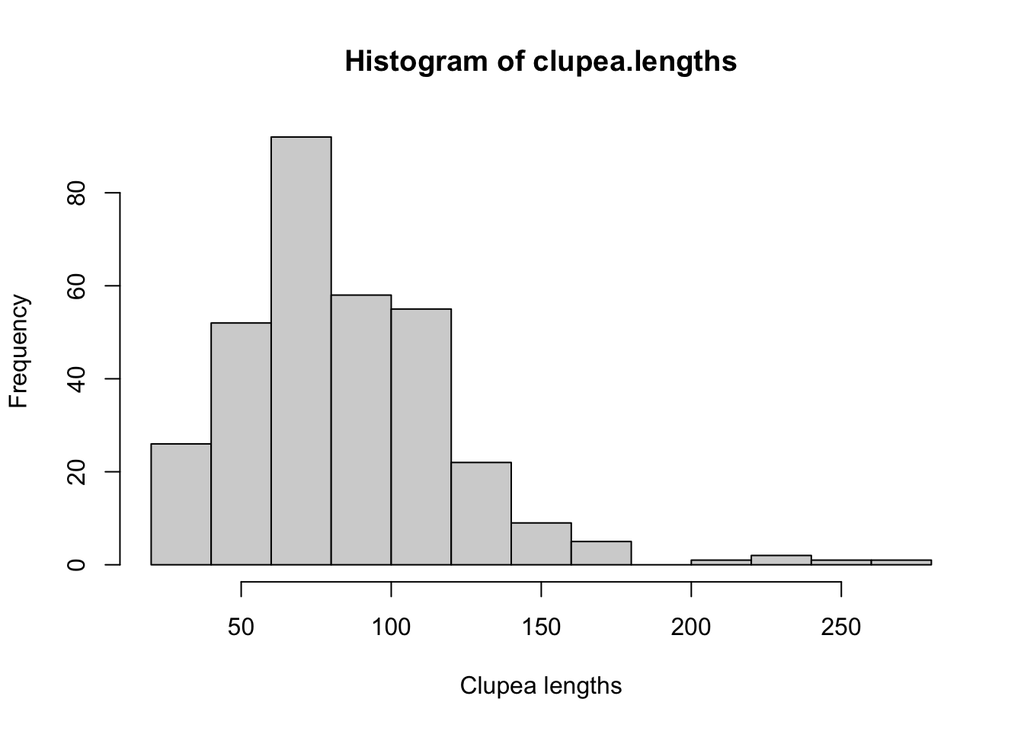

```r
hist(clupea.lengths,
     xlab = "Clupea lengths")
```

2. Create a cumulative frequency plot of these data.

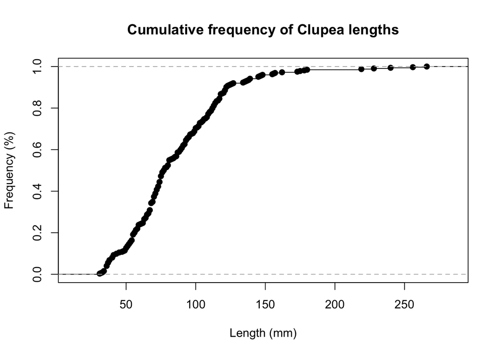

```r
plot(ecdf(clupea.lengths),
     # change y lab
     ylab = "Frequency (%)",
     # change x lab
     xlab = "Length (mm)",
     # change title
     main = "Cumulative frequency of Clupea lengths")
```

3. Calculate the kurtosis of these data, and make a conclusion about the kurtosis of the dataset.

```r
(kurtosis(clupea.lengths) - 3) |> round(2)
```

```
## [1] 4.26
```

The kurtosis of the *Clupea* lengths is 4.26, which is leptokurtic.

4. Calculate the skewness of these data, and make a conclusion about the skewness of the dataset.

```r
skewness(clupea.lengths) |> round(2)
```

```
## [1] 1.49
```

These data are positively skewed (i.e., skewed to the right).

5. Create a boxplot of these data.

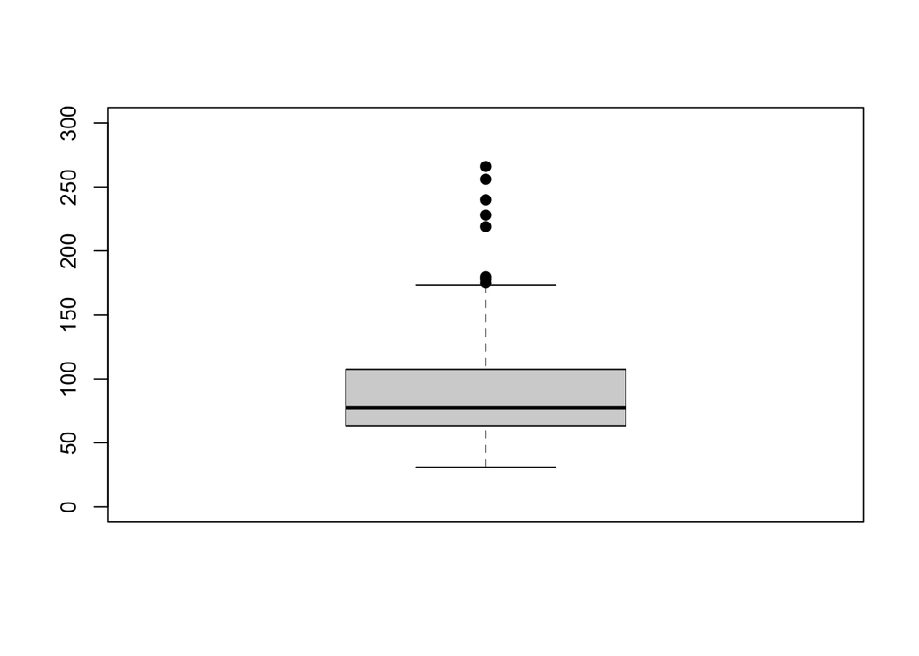

```r
boxplot(clupea.lengths,
        ylim = c(0,300),
        pch = 19)
```

### Problem 2

The Fremont Bridge in Seattle is one of the only bridges that connects the north and south sides of the city, crossing the Fremont Cut - a navigational canal between the Puget Sound and Lake Union & Lake Washington. As such, it is an important transportation corridor. We will be looking at counts of bicyclists, taken hourly for the east (predominately northbound) side over a seven year period [@weber_fremont_2019]. This dataset has 56,904 records - thus, this is not something that would be easily done without the use of a program like *R*!

```r
bicycles <- read_csv("https://zenodo.org/records/2648564/files/Fremont_Bridge_Hourly_Bicycle_Counts_by_Month_October_2012_to_present.csv")

bike.count <- bicycles$`Fremont Bridge East Sidewalk` |>
  na.omit()
```

1. Create a histogram of these data.

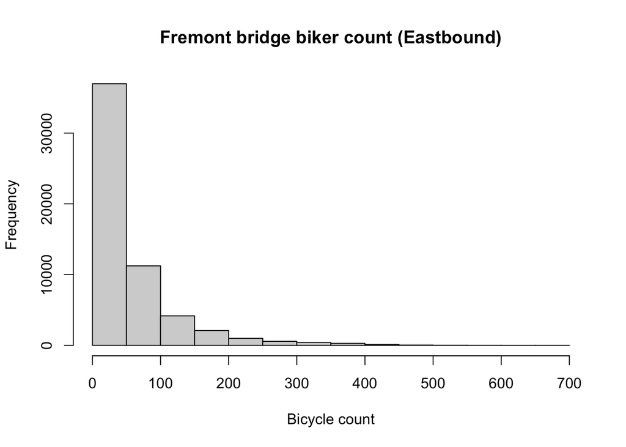

```r
hist(bike.count,
     xlab = "Bicycle count",
     main = "Fremont bridge biker count (Eastbound)")
```

2. Create a cumulative frequency plot of these data.

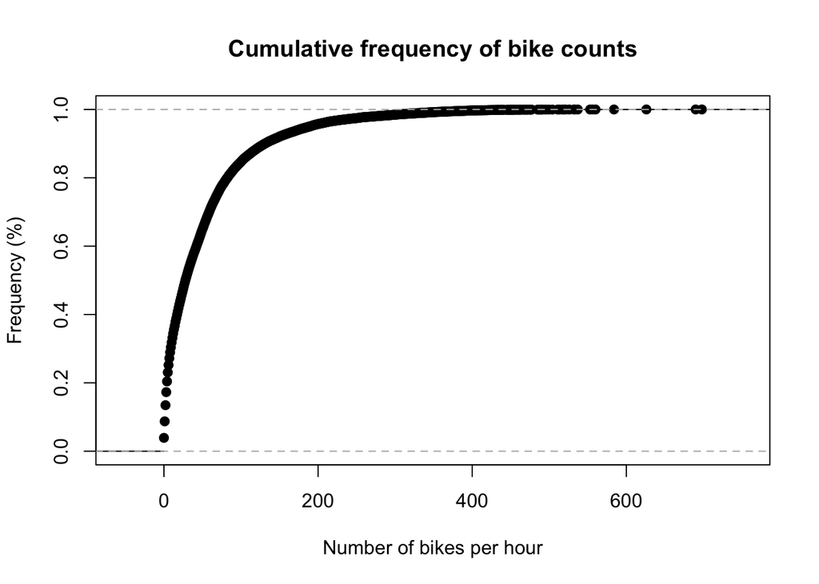

```r
plot(ecdf(bike.count),
     xlab = "Number of bikes per hour",
     ylab = "Frequency (%)",
     main = "Cumulative frequency of bike counts")
```

3. Calculate the kurtosis of these data, and make a conclusion about the kurtosis of the dataset.

```r
(kurtosis(bike.count)-3) |> round(2)
```

```
## [1] 8.06
```

These data are significantly leptokurtic.

4. Calculate the skewness of these data, and make a conclusion about the skewness of the dataset.

```r
skewness(bike.count) |> round(2)
```

```
## [1] 2.49
```

These data are significantly skewed to the right (i.e., positively).

5. Create a boxplot of these data.

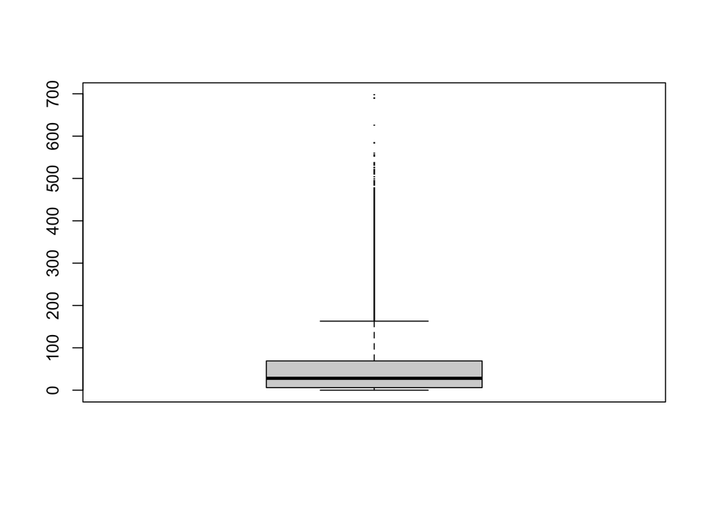

```r
boxplot(bike.count, pch = ".")
```

We have lots of positive outliers.

### Problem 3

Take the object `bike.count` from the previous problem and perform a *log transformation* of the data. To do this, we will take the natural log of the dataset plus one. We must add 1 to every value in the dataset, because the natural log of 0 is negative infinity; adding one makes every value in the dataset quantifiable as the minimum value for any count data is 0.

Perform the following action on your computer, replacing `x` with your `bike.data` object. Name your object `log.bikes` instead of `log.x`.

```r
log.x <- log(x + 1)
```

After performing the log transformation, complete the following.

```r
log.bike.count <- log(bike.count + 1)
```

1. Create a histogram of these data.

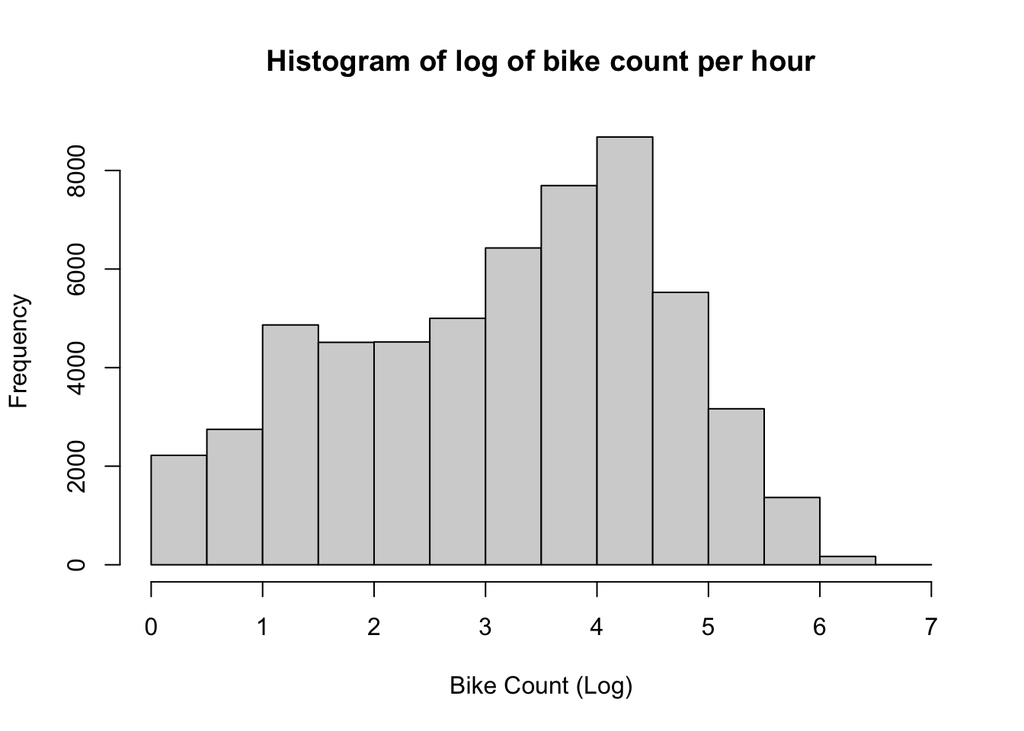

```r
hist(log.bike.count,
     xlab = "Bike Count (Log)",
     main = "Histogram of log of bike count per hour")
```

2. Create a cumulative frequency plot of these data.

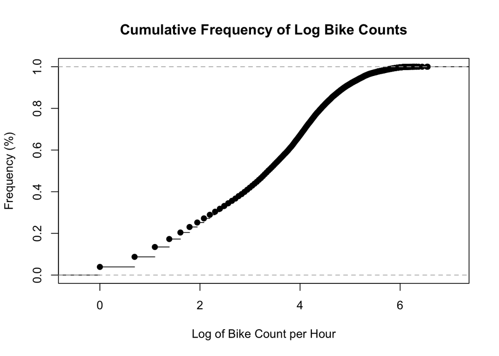

```r
plot(ecdf(log.bike.count),
     ylab = "Frequency (%)",
     xlab = "Log of Bike Count per Hour",
     main = "Cumulative Frequency of Log Bike Counts")
```

3. Calculate the kurtosis of these data, and make a conclusion about the kurtosis of the dataset.

```r
(kurtosis(log.bike.count)-3) |> round(2)
```

```
## [1] -0.74
```

4. Calculate the skewness of these data, and make a conclusion about the skewness of the dataset.

```r
skewness(log.bike.count)
```

```
## [1] -0.3561913
```

These data are not significantly skewed.

5. Create a boxplot of these data.

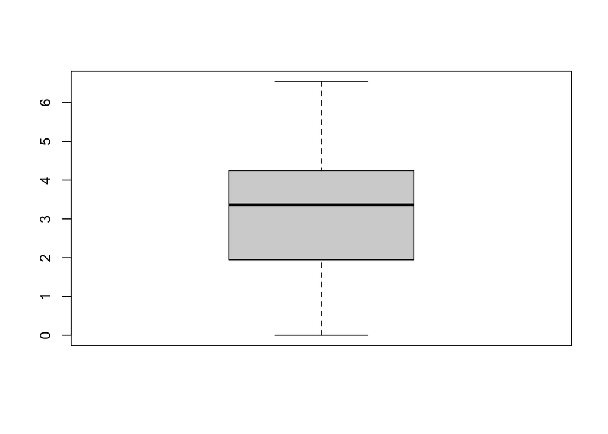

```r
boxplot(log.bike.count)
```

There are no outliers in the dataset.

6. How did the log transformation change these data?

The log transformation made the data much more normal and easier to analyze.

### Problem 4

Is there pseudoreplication in the bicycle dataset? Why or why not?

There is potentially pseudoreplication, as we don’t know if the same people are crossing the bridge multiple times in a day or multiple times within the study period.